# Project: Exploration of Income Tax Data

- The IRS supplies personal income tax statistics organized by zip code.
- Includes data on income, special tax credits and deductions, number of dependents, and more.
- Over 27,000 zip codes with 120 features for each one.
- The distribution has a long tail extending to $1.2 million.

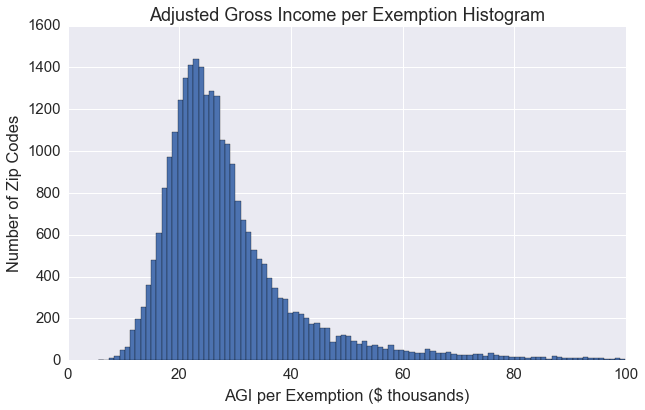

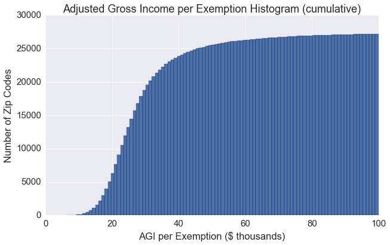

```python
agi_data = map_data.agi_per_exemp
agi_data[agi_data < 100].hist(bins = 100)


plt.title('Adjusted Gross Income per Exemption Histogram')
plt.xlabel('AGI per Exemption ($ thousands)')
plt.ylabel('Number of Zip Codes')
plt.show()

agi_data[agi_data < 100].hist(bins = 100, cumulative = True)
plt.title('Adjusted Gross Income per Exemption Histogram (cumulative)')
plt.xlabel('AGI per Exemption ($ thousands)')
plt.ylabel('Number of Zip Codes')
plt.show()
```

## Geographical Map of Income

- Using the Basemap package and zip code shapefiles taken from the US Census website, we can map out the income levels by zip code.
- The first map shows all of the zip codes in the dataset.
- Not all of the map is populated (the white spots are missing). Those regions have very few people.

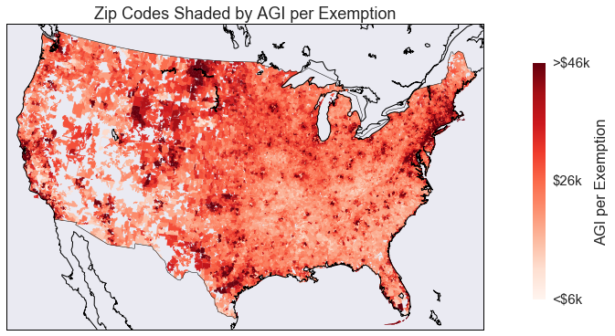

```python
draw_map(0,.9, True)
```

- The following series of maps shades the areas where the people belonging to different quantiles of personal income live.

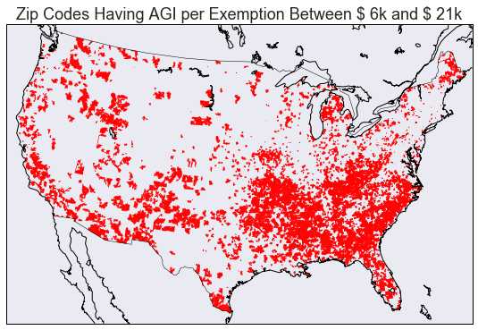

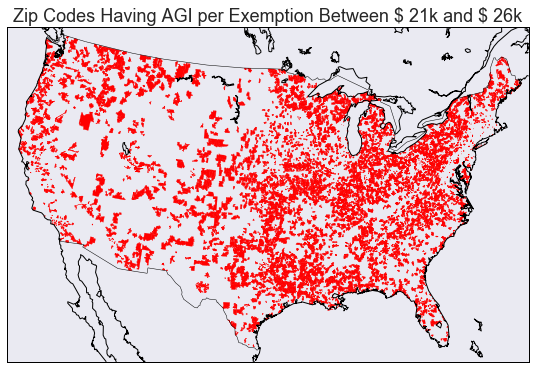

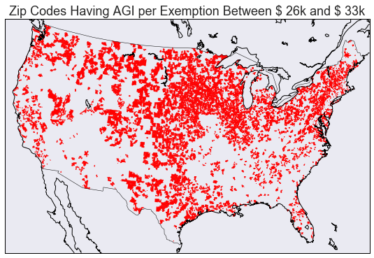

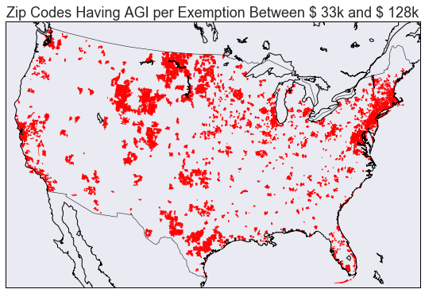

```python
draw_map(0,.25, False)
draw_map(.25,.5, False)
draw_map(.5,.75, False)
draw_map(.75,.99, False)
```

- The next map represents the top 1% of zip codes (which is not the same as the top 1% of people).
- New York City, San Francisco, and Los Angeles are expected.
- The richest counties in America also include McMullen County, Texas and Teton County, Wyoming. Both of these are clearly visible on the map.

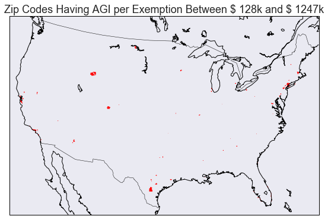

```python
draw_map(.99,1, False)
```

## Predict Income Using Other Categories

- The tax return contains a lot of other information besides income: business partnerships, foreign taxes paid, etc.
- Which of these features can be used as predictors of income?
- We can directly answer this question using machine learning to construct a model of income based on these features.
- Features have to be carefully chosen and normalized.
  - Don't want to accidentally include features that directly give the amount of income.
  - Certain features have to be dropped completely, and others are normalized by dividing by total AGI (for dollar amounts) or total number of returns (for counts).
- XGBoost is used to construct the actual model.
  - Feature importance is determined by how often the model makes use of the feature.

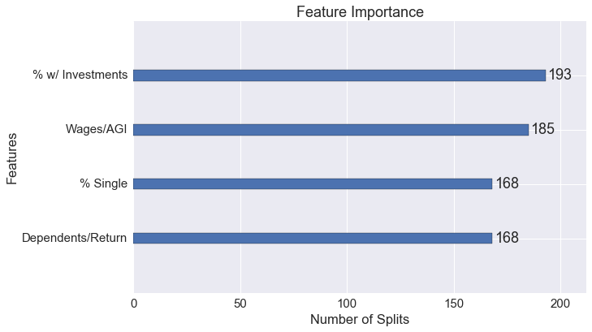

```python
xgb.plot_importance(bst, max_num_features = 4, xlabel = 'Number of Splits', title = 'Feature Importance')
plt.show()
```

The most important features are

1. the fraction of returns with investement income
2. the fraction of AGI coming from wages
3. the fraction of single returns (as opposed to joint or head-of-household)
4. the number of dependents per return

To look at these features in greater depth, we analyze their correlations with each other and with AGI per Exemption. That is done in the following plots:

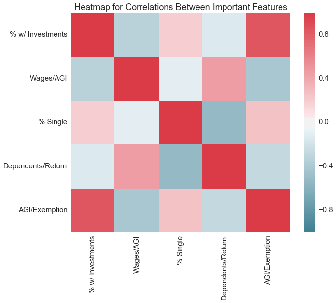

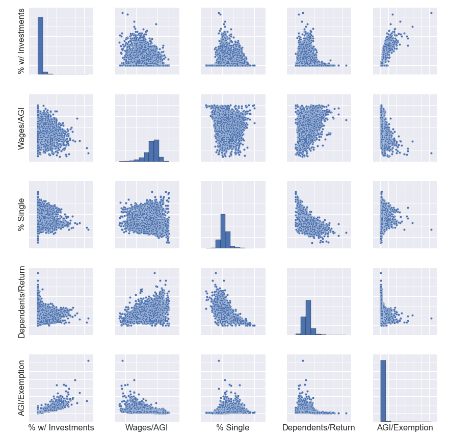

```python
import warnings
warnings.filterwarnings("ignore", category=DeprecationWarning)

model_df.rename(columns = labels, inplace = True)
imp_features = ['% w/ Investments', 'Wages/AGI', '% Single', 'Dependents/Return', 'Total Credits/AGI']
f, ax = plt.subplots(figsize=(10, 8))
corr = model_df[imp_features[:4] + ['AGI/Exemption']].corr()
sns.heatmap(corr, mask=np.zeros_like(corr, dtype=np.bool), cmap=sns.diverging_palette(220, 10, as_cmap=True),
            square=True, ax=ax)
plt.title('Heatmap for Correlations Between Important Features')
plt.show()
pp = sns.pairplot( model_df[imp_features[:4] + ['AGI/Exemption']])
for i in range(5):
    plt.setp(pp.axes[i,0].get_yticklabels(), visible=False)
    plt.setp(pp.axes[4,i].get_xticklabels(), visible=False)
plt.show()
```

- % w/Investements has the highest correlation coefficient with AGI/Exemption out of all features at 0.85.
- Wages/AGI has the largest-in-magnitude negative correlation at -0.41
- % Single and Dependents/Return are well-correlated with each other and have moderate correlations with AGI/Exemption.
  - Perhaps their combined effect is useful for the model?

```python
import IPython.core.display as di

# This line will hide code by default when the notebook is exported as HTML
di.display_html('<script>jQuery(function() {if (jQuery("body.notebook_app").length == 0) { jQuery(".input_area").toggle(); jQuery(".prompt").toggle();}});</script>', raw=True)

# This line will add a button to toggle visibility of code blocks, for use with the HTML export version
#di.display_html('''<button onclick="jQuery('.input_area').toggle(); jQuery('.prompt').toggle();">Toggle code</button>''', raw=True)
```